# Analysis of exposures with a neutral discourse context

This notebook analyzes the generalization patterns of novel dative-verb learners based on the factors of exposure contexts which situate the novel verb in a neutral discourse context where only the agent is given. For example:

```
DO: look mommy is walking around . mommy [verbed] me a ball.
PP: look mommy is walking around . mommy [verbed] a ball to me .
```

## Loading Data (code hidden)

```
 Found 500 records...
 Found 1000 records...
 Found 1500 records...
 Found 1620 records...
 Imported 1620 records. Simplifying...

 Found 255 records...
 Imported 255 records. Simplifying...
```

## Cross Dative Generalization

Investigating alternate-form generalization patterns of the learner when it is exposed to the double object dative vs. prepositional object dative.

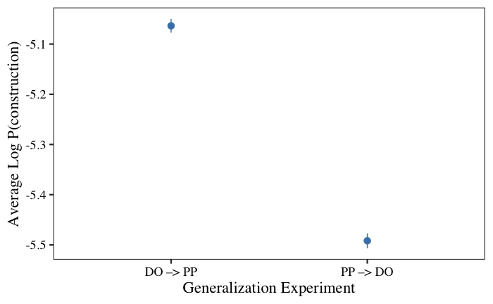

## Conwell’s “me” finding (2019):

Pronominal recipients enable DO comprehension in children, so if we were to believe that comprehension is a precondition to generalization, then pronominal recipients should also encourage generalization:

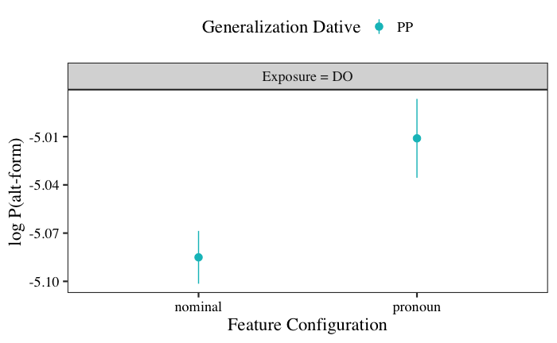

## Replicating Arunachalam (2017):

Only looking at definite themes and recipients:

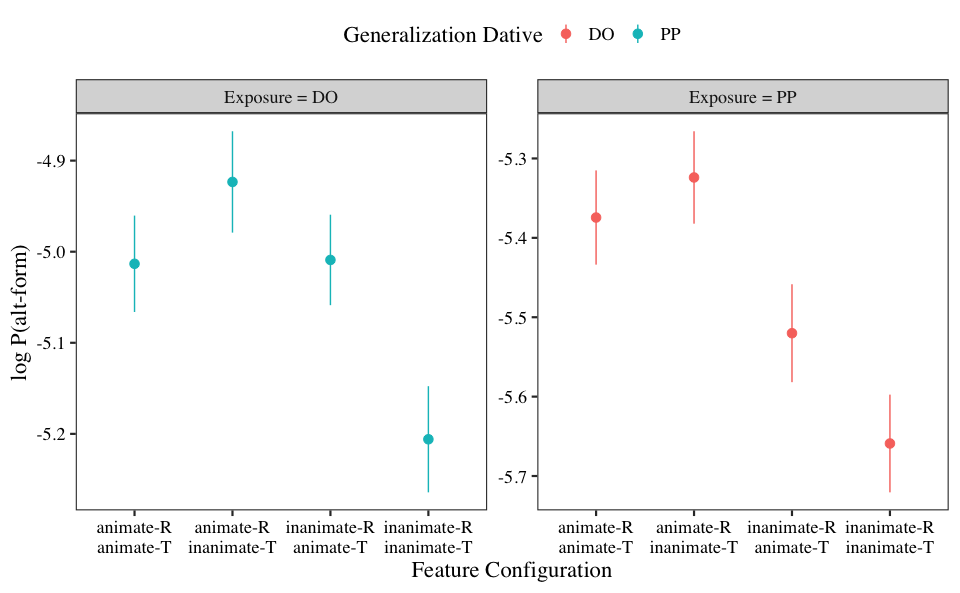

## Interaction terms

The design of interaction terms is a bit tricky. Due to our design, the pronominality might interact with the animacy of a given argument, but animacy and pronominality might also interact across arguments – e.g., if theme is inanimate then LMs might prefer animate recipients (if they are sensitive to the semantics of the dative construction – caused possession/motion). This means we should include the following interaction terms:

```
- theme_animacy * theme_pronominality
- recipient_animacy * recipient_pronominality
- theme_animacy * recipient_animacy
- theme_pronominality * recipient pronominality
```

## DO –> PP analysis

```r
do_pp <- coded_results %>%
  filter(adaptation_dative == "do", generalization_dative == "pp")

# interactions between theme-animacy and recipient animacy; theme-pronominality and recipient-pronominality

fit_tara_tprp_interaction_dopp <- lmer(best ~
                                    theme_animacy * theme_pronominality +
                                    recipient_animacy * recipient_pronominality +
                                    theme_animacy * recipient_animacy +
                                    theme_pronominality * recipient_pronominality +
                                    theme_definiteness + recipient_definiteness +
                                    theme_length + recipient_length +
                                    (1|model) + (1|item_id), data = do_pp)

summary(fit_tara_tprp_interaction_dopp, correlation = FALSE)
```

```
Linear mixed model fit by REML. t-tests use Satterthwaite's method ['lmerModLmerTest']
Formula: best ~ theme_animacy * theme_pronominality + recipient_animacy *
    recipient_pronominality + theme_animacy * recipient_animacy +
    theme_pronominality * recipient_pronominality + theme_definiteness +
    recipient_definiteness + theme_length + recipient_length +      (1 | model) + (1 | item_id)
   Data: do_pp

REML criterion at convergence: 13858.5

Scaled residuals:
    Min      1Q  Median      3Q     Max
-4.8804 -0.6496  0.0545  0.7242  2.5297

Random effects:
 Groups   Name        Variance Std.Dev.
 item_id  (Intercept) 0.03294  0.1815
 model    (Intercept) 0.05442  0.2333
 Residual             0.29676  0.5448
Number of obs: 8100, groups:  item_id, 810; model, 10

Fixed effects:
                                             Estimate Std. Error        df t value Pr(>|t|)
(Intercept)                                  -5.10868    0.07516   9.56967 -67.971 3.59e-14 ***
theme_animacy                                -0.01649    0.01969 797.00003  -0.837 0.402617
theme_pronominality                          -0.08369    0.02685 797.00003  -3.117 0.001891 **
recipient_animacy                             0.13573    0.01969 797.00003   6.894 1.10e-11 ***
recipient_pronominality                       0.02750    0.02685 797.00003   1.024 0.306030
theme_definiteness                           -0.01356    0.01769 797.00003  -0.767 0.443562
recipient_definiteness                        0.05807    0.01769 797.00003   3.283 0.001071 **
theme_length                                  0.04604    0.02085 797.00003   2.208 0.027559 *
recipient_length                              0.14238    0.02085 797.00003   6.828 1.71e-11 ***
theme_animacy:theme_pronominality             0.05630    0.03937 797.00003   1.430 0.153130
recipient_animacy:recipient_pronominality     0.17328    0.03937 797.00003   4.401 1.23e-05 ***
theme_animacy:recipient_animacy              -0.20436    0.03528 797.00003  -5.793 9.94e-09 ***
theme_pronominality:recipient_pronominality   0.18898    0.04948 797.00003   3.819 0.000144 ***
---
Signif. codes:  0 ‘***’ 0.001 ‘**’ 0.01 ‘*’ 0.05 ‘.’ 0.1 ‘ ’ 1
```

## PP –> DO Analysis

```r
pp_do <- coded_results %>%
  filter(adaptation_dative == "pp", generalization_dative == "do")

fit_tara_tprp_interaction_ppdo <- lmer(best ~
                                    theme_animacy * theme_pronominality +
                                    recipient_animacy * recipient_pronominality +
                                    theme_animacy * recipient_animacy +
                                    theme_pronominality * recipient_pronominality +
                                    theme_definiteness + recipient_definiteness +
                                    theme_length  + recipient_length +
                                    (1|model) + (1|item_id), data = pp_do)

summary(fit_tara_tprp_interaction_ppdo, correlation = FALSE)
```

```
Linear mixed model fit by REML. t-tests use Satterthwaite's method ['lmerModLmerTest']
Formula: best ~ theme_animacy * theme_pronominality + recipient_animacy *
    recipient_pronominality + theme_animacy * recipient_animacy +
    theme_pronominality * recipient_pronominality + theme_definiteness +
    recipient_definiteness + theme_length + recipient_length +      (1 | model) + (1 | item_id)
   Data: pp_do

REML criterion at convergence: 15073.3

Scaled residuals:
    Min      1Q  Median      3Q     Max
-5.7034 -0.6519  0.0356  0.6929  3.0711

Random effects:
 Groups   Name        Variance Std.Dev.
 item_id  (Intercept) 0.04736  0.2176
 model    (Intercept) 0.04871  0.2207
 Residual             0.34075  0.5837
Number of obs: 8100, groups:  item_id, 810; model, 10

Fixed effects:
                                             Estimate Std. Error        df t value Pr(>|t|)
(Intercept)                                  -5.53234    0.07170   9.85308 -77.159 4.89e-15 ***
theme_animacy                                 0.01945    0.02245 797.00045   0.866  0.38666
theme_pronominality                           0.07710    0.03062 797.00045   2.518  0.01199 *
recipient_animacy                             0.09310    0.02245 797.00045   4.147 3.73e-05 ***
recipient_pronominality                       0.03265    0.03062 797.00045   1.066  0.28660
theme_definiteness                            0.03814    0.02017 797.00045   1.891  0.05900 .
recipient_definiteness                        0.00324    0.02017 797.00045   0.161  0.87241
theme_length                                  0.25105    0.02378 797.00045  10.557  < 2e-16 ***
recipient_length                              0.16284    0.02378 797.00045   6.848 1.50e-11 ***
theme_animacy:theme_pronominality            -0.10848    0.04490 797.00045  -2.416  0.01592 *
recipient_animacy:recipient_pronominality    -0.03645    0.04490 797.00045  -0.812  0.41722
theme_animacy:recipient_animacy              -0.06932    0.04023 797.00045  -1.723  0.08525 .
theme_pronominality:recipient_pronominality   0.21501    0.05643 797.00045   3.810  0.00015 ***
---
Signif. codes:  0 ‘***’ 0.001 ‘**’ 0.01 ‘*’ 0.05 ‘.’ 0.1 ‘ ’ 1
```

## Attempt at displaying DO -> PP and PP -> DO in same table:

```r
tidy(fit_tara_tprp_interaction_dopp) %>%
  filter(effect == "fixed") %>%
  select(term, do_pp_estimate = estimate, do_pp_pval = p.value) %>%
  inner_join(
    tidy(fit_tara_tprp_interaction_ppdo) %>%
      filter(effect == "fixed") %>%
      select(term, pp_do_estimate = estimate, pp_do_pval = p.value)
  ) %>%
  mutate(
    # do_pp_estimate = format(do_pp_estimate , scientific=TRUE),
    # pp_do_estimate = format(pp_do_estimate, scientific=TRUE),
    do_pp_estimate = round(do_pp_estimate, 4),
    pp_do_estimate = round(pp_do_estimate, 4),
    do_pp_signif = case_when(
      do_pp_pval < 0.05 ~ "**",
      TRUE ~ as.character(round(do_pp_pval, 4))
    ),
    pp_do_signif = case_when(
      pp_do_pval < 0.05 ~ "**",
      TRUE ~ as.character(round(pp_do_pval, 4))
    )
  ) %>%
  select(term, do_pp_estimate, do_pp_signif, pp_do_estimate, pp_do_signif) %>%
  DT::datatable(options = list(pageLength = 14))
```

|  | term | do_pp_estimate | do_pp_signif | pp_do_estimate | pp_do_signif |
| --- | --- | --- | --- | --- | --- |
| 1 | (Intercept) | -5.1087 | ** | -5.5323 | ** |
| 2 | theme_animacy | -0.0165 | 0.4026 | 0.0194 | 0.3867 |
| 3 | theme_pronominality | -0.0837 | ** | 0.0771 | ** |
| 4 | recipient_animacy | 0.1357 | ** | 0.0931 | ** |
| 5 | recipient_pronominality | 0.0275 | 0.306 | 0.0326 | 0.2866 |
| 6 | theme_definiteness | -0.0136 | 0.4436 | 0.0381 | 0.059 |
| 7 | recipient_definiteness | 0.0581 | ** | 0.0032 | 0.8724 |
| 8 | theme_length | 0.046 | ** | 0.2511 | ** |
| 9 | recipient_length | 0.1424 | ** | 0.1628 | ** |
| 10 | theme_animacy:theme_pronominality | 0.0563 | 0.1531 | -0.1085 | ** |

[output cut: 3 more lines]

## LMER for Arunachalam (2017)

```r
do_pp_sudha <- sudha %>%
  filter(adaptation_dative == "do", generalization_dative == "pp")

# interactions between theme-animacy and recipient animacy; theme-pronominality and recipient-pronominality

fit_tara_tprp_interaction_dopp_sudha <- lmer(best ~
                                    theme_animacy * theme_pronominality +
                                    theme_pronominality * recipient_pronominality +
                                    theme_length  + recipient_length +
                                    (1|model) + (1|item_id), data = do_pp_sudha)

summary(fit_tara_tprp_interaction_dopp_sudha, correlation = FALSE)
```

```
Linear mixed model fit by REML. t-tests use Satterthwaite's method ['lmerModLmerTest']
Formula: best ~ theme_animacy * theme_pronominality + theme_pronominality *
    recipient_pronominality + theme_length + recipient_length +      (1 | model) + (1 | item_id)
   Data: do_pp_sudha

REML criterion at convergence: 1869.2

Scaled residuals:
    Min      1Q  Median      3Q     Max
-3.7715 -0.6350  0.0161  0.6996  2.5612

Random effects:
 Groups   Name        Variance Std.Dev.
 item_id  (Intercept) 0.03221  0.1795
 model    (Intercept) 0.07388  0.2718
 Residual             0.29205  0.5404
Number of obs: 1080, groups:  item_id, 108; model, 10

Fixed effects:
                                             Estimate Std. Error        df t value Pr(>|t|)
(Intercept)                                  -5.00812    0.09238  11.15239 -54.212 7.26e-15 ***
theme_animacy                                -0.06339    0.05059 100.00036  -1.253 0.213107
theme_pronominality                          -0.10709    0.06109 100.00036  -1.753 0.082655 .
recipient_pronominality                       0.16110    0.06109 100.00036   2.637 0.009696 **
theme_length                                  0.04715    0.05841 100.00036   0.807 0.421506
recipient_length                              0.22424    0.05841 100.00036   3.839 0.000217 ***
theme_animacy:theme_pronominality             0.15890    0.10117 100.00036   1.571 0.119438
theme_pronominality:recipient_pronominality   0.12780    0.10731 100.00036   1.191 0.236490
---
Signif. codes:  0 ‘***’ 0.001 ‘**’ 0.01 ‘*’ 0.05 ‘.’ 0.1 ‘ ’ 1
```

```r
pp_do_sudha <- sudha %>%
  filter(adaptation_dative == "pp", generalization_dative == "do")

# interactions between theme-animacy and recipient animacy; theme-pronominality and recipient-pronominality

fit_tara_tprp_interaction_ppdo_sudha <- lmer(best ~
                                    theme_animacy * theme_pronominality +
                                    theme_pronominality * recipient_pronominality +
                                    theme_length  + recipient_length +
                                    (1|model) + (1|item_id), data = pp_do_sudha)

summary(fit_tara_tprp_interaction_ppdo_sudha, correlation = FALSE)
```

```
Linear mixed model fit by REML. t-tests use Satterthwaite's method ['lmerModLmerTest']
Formula: best ~ theme_animacy * theme_pronominality + theme_pronominality *
    recipient_pronominality + theme_length + recipient_length +      (1 | model) + (1 | item_id)
   Data: pp_do_sudha

REML criterion at convergence: 1938

Scaled residuals:
    Min      1Q  Median      3Q     Max
-3.8158 -0.6406  0.0538  0.7173  2.6652

Random effects:
 Groups   Name        Variance Std.Dev.
 item_id  (Intercept) 0.04532  0.2129
 model    (Intercept) 0.05821  0.2413
 Residual             0.30743  0.5545
Number of obs: 1080, groups:  item_id, 108; model, 10

Fixed effects:
                                             Estimate Std. Error        df t value Pr(>|t|)
(Intercept)                                  -5.40692    0.08509  12.59567 -63.543  < 2e-16 ***
theme_animacy                                -0.10031    0.05630  99.99946  -1.782  0.07780 .
theme_pronominality                           0.34200    0.06798  99.99946   5.031 2.16e-06 ***
recipient_pronominality                      -0.10215    0.06798  99.99946  -1.503  0.13612
theme_length                                  0.30887    0.06501  99.99946   4.751 6.77e-06 ***
recipient_length                              0.26614    0.06501  99.99946   4.094 8.61e-05 ***
theme_animacy:theme_pronominality            -0.29916    0.11259  99.99946  -2.657  0.00918 **
theme_pronominality:recipient_pronominality   0.06806    0.11942  99.99946   0.570  0.57000
---
Signif. codes:  0 ‘***’ 0.001 ‘**’ 0.01 ‘*’ 0.05 ‘.’ 0.1 ‘ ’ 1
```

```r
tidy(fit_tara_tprp_interaction_dopp_sudha) %>%
  filter(effect == "fixed") %>%
  select(term, do_pp_estimate = estimate, do_pp_pval = p.value) %>%
  inner_join(
    tidy(fit_tara_tprp_interaction_ppdo_sudha) %>%
      filter(effect == "fixed") %>%
      select(term, pp_do_estimate = estimate, pp_do_pval = p.value)
  ) %>%
  mutate(
    # do_pp_estimate = format(do_pp_estimate , scientific=TRUE),
    # pp_do_estimate = format(pp_do_estimate, scientific=TRUE),
    do_pp_estimate = round(do_pp_estimate, 4),
    pp_do_estimate = round(pp_do_estimate, 4),
    do_pp_signif = case_when(
      do_pp_pval < 0.05 ~ "**",
      TRUE ~ as.character(round(do_pp_pval, 4))
    ),
    pp_do_signif = case_when(
      pp_do_pval < 0.05 ~ "**",
      TRUE ~ as.character(round(pp_do_pval, 4))
    )
  ) %>%
  select(term, do_pp_estimate, do_pp_signif, pp_do_estimate, pp_do_signif) %>%
  DT::datatable(options = list(pageLength = 14))
```

|  | term | do_pp_estimate | do_pp_signif | pp_do_estimate | pp_do_signif |
| --- | --- | --- | --- | --- | --- |
| 1 | (Intercept) | -5.0081 | ** | -5.4069 | ** |
| 2 | theme_animacy | -0.0634 | 0.2131 | -0.1003 | 0.0778 |
| 3 | theme_pronominality | -0.1071 | 0.0827 | 0.342 | ** |
| 4 | recipient_pronominality | 0.1611 | ** | -0.1021 | 0.1361 |
| 5 | theme_length | 0.0471 | 0.4215 | 0.3089 | ** |
| 6 | recipient_length | 0.2242 | ** | 0.2661 | ** |
| 7 | theme_animacy:theme_pronominality | 0.1589 | 0.1194 | -0.2992 | ** |
| 8 | theme_pronominality:recipient_pronominality | 0.1278 | 0.2365 | 0.0681 | 0.57 |